# CPLN 675 - Urban Growth Modeling, 2022

Alexander Nelms

5/9/2022

# 1. Introduction

Many urban processes don’t obey borders. A commuter might cross multiple city & county boundaries in a single trip. When a young couple is looking to buy a house & start a family, they might not have specific preferences on which incorporated city they are in. Instead, they might consider the school district, housing prices, and where the future will treat them the best.

For many American regions, there isn’t necessarily a single governing-body that sets policies for the entire region. The state is too large to focus on one single region. Counties and cities can only focus on their share of their region – even if that means they make selfish policy decisions. So when these agencies get together to make a regional plan & prediction, it is a brief moment where all policy makers attempt to align their interests.

For the **San Francisco Bay Area**, this fractured policy-making has had drastic consequences. Each city has largely been conservative in allowing housing units to be built. Because of the lack of development across the board, there has been an extreme housing shortage – leading to the region being a leader in housing price costs, homelessness per capita, and income inequality. The figure below visualizes the shortage of permitted units. [[source: Plan Bay Area 2040](http://2040.planbayarea.org/the-bay-area-today)]

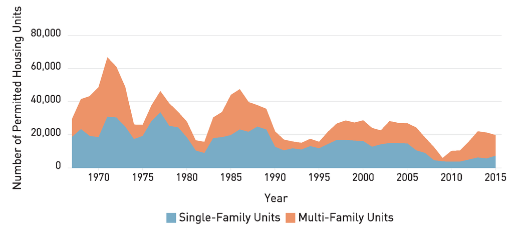

**Plan Bay Area 2040** (2013) was the most recent plan for the Bay Area. According to a recent review of the plan’s projections [[source](https://mtc.ca.gov/sites/default/files/motm_5_17_18.pdf)], the 2040 housing unit targets have recently fallen flat. Based on the rate of housing growth in the last 10 years, San Francisco would meet their 2040 housing target in 2063. San Jose in 2066. Oakland in 2295.

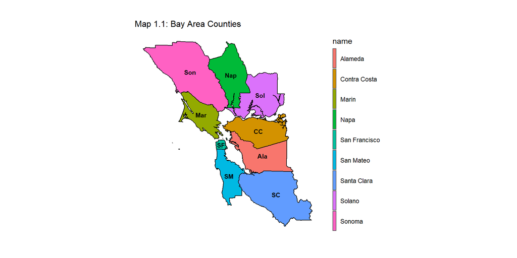

```r
CA_proj = st_crs('EPSG:2227')
proj_crs = CA_proj

path = 'data/sf_counties_clipped.geojson'

sf.counties =
  st_read(path) %>%
  st_as_sf() %>%
  mutate(
    county.id = fipco,
    geometry = geometry %>% st_make_valid()
    ) %>%
  dplyr::select(county.id) %>%
  st_transform(CA_proj)

sf.MSA =
  sf.counties %>%
  mutate(ID=1) %>%
  group_by(ID) %>%
  summarize(geometry = st_union(geometry)) %>%
  st_transform(CA_proj)
  #st_transform('ESRI:102741') # JE Note: added 'ESRI:' in front of projection

sf.extent = sf.MSA %>% extent()
sf.bbox = sf.MSA %>% st_bbox() %>% st_as_sfc()


from = c("001", "013", "041", "055", "075", "081", "085", "095", "097")
to = c("Alameda", "Contra Costa", "Marin", "Napa", "San Francisco", "San Mateo", "Santa Clara", "Solano", "Sonoma")

replace_list = function(target_list, from, to){
  lookup = data.frame(from = from, to = to)
  return(lookup$to[match(unlist(target_list), lookup$from)])
}

sf.counties$name = replace_list(sf.counties$county.id, from, to)

geom_county = function(
  data = sf.counties,
  county = 'All',
  fill = 'transparent', color='black',
  lwd=.5, ...
  ){
  focus_county = data
  if (county != 'All'){
    focus_county =
      focus_county %>%
        filter(name==county)}
    c_plot =
      geom_sf(
        data = focus_county,
        fill = fill,
        color=color,
          lwd=lwd, ...)
    return(c_plot)}

# plot text
geom_text_sf = function(
  sf.focus.labels,
  fontface='bold', color='black', check_overlap = TRUE,
  ...
){
  labels =
    geom_text(
        data=sf.focus.labels, check_overlap=check_overlap,
        fontface=fontface, color=color,
        aes(x=lon,y=lat, label=label), ...)
  return(labels)}

# turn sf polys to label

sf_to_labels = function(
  sf_focus, label_field
){
  sf.focus.labels =
    sf_focus %>%
    st_centroid(., of_largest_polygon = TRUE) %>%
    mutate(
      lon =
        map_dbl(
          geometry,
          ~st_centroid(.x,
                       of_largest_polygon = TRUE,
                       quiet = TRUE,)[[1]]),
      lat =
        map_dbl(
          geometry,
          ~st_centroid(.x,
                       of_largest_polygon = TRUE,
                       quiet = TRUE,)[[2]])
    )
  sf.focus.labels$label = sf.focus.labels[[label_field]]
  return(sf.focus.labels %>% dplyr::select(label, lon, lat))
}

get_first_letter = function(string, sec=1){
  substring(string, 1, sec)
}
get_first_letters = function(full_string){
  string_list = strsplit(full_string," ")
  strings = sapply(string_list, function(strs){
    sec = 1
    if (lengths(string_list)==1){
      sec=3
    }
    get_first_letter(strs, sec=sec)})
  strings =
    paste(strings, collapse="")
  return(strings)
}

sf.counties_labels =
  sf.counties %>%
  mutate(name = sapply(name, function(strss) get_first_letters(strss)))

geom_county_text = function(
  data = sf.counties_labels,
  size=3
  ){
  geom_text_sf(
    sf_to_labels(
      data,'name'),
    size = size)
}


ggplot() +
  geom_sf(data=sf.counties, aes(fill=name)) +
  geom_county_text() +
  geom_county() +
  #geom_county(county='San Francisco') +
  labs(title = "Map 1.1: Bay Area Counties") +
  mapTheme
```

## 1.1. Report Contents

With Plan Bay Area 2040 in mind, this report will help understand how *(and where)* San Francisco has developed in the last 20 years. Specifically this report will be split into 4 sections to both understand and re-predict development:

**Section 1.** Visualizing 2001, 2009, & 2019 land-use & change

**Section 2.** Predict Land-Use Change from 2009 to 2019

**Section 3.** Scenario 1: What would development look based on 2030 population predictions?

**Section 4.** Scenario 2: What if Bay Area Regional Transit was expanded before 2019?

```r
#this function converts a column in to quintiles. It is used for mapping.
quintileBreaks = function(df,variable) {
    as.character(quantile(df[[variable]],
                          c(.01,.2,.4,.6,.8),na.rm=T))
}

#This function can be used to convert a polygon sf to centroids xy coords.
xyC = function(aPolygonSF) {
  as.data.frame(
    cbind(x=st_coordinates(st_centroid(aPolygonSF))[,1],
          y=st_coordinates(st_centroid(aPolygonSF))[,2]))
}

#this function convert a raster to a data frame so it can be plotted in ggplot
rast = function(inRaster) {
  data.frame(
    xyFromCell(inRaster, 1:ncell(inRaster)),
    value = getValues(inRaster)) }

# rename first col of dataframe
rename_first_col = function(focus_sf, new_name, col_idx = 1){
  names(focus_sf)[names(focus_sf) == names(focus_sf)[col_idx]] = new_name
  return(focus_sf)
}

# remove duplicate cols during a join
## if i do the same join twice
select_not_cols = function(focus_sf, bad_cols){
  bad_cols = c(bad_cols)
  cols = colnames(focus_sf)
  cols = cols[!(cols %in% bad_cols)]
  return(focus_sf %>% dplyr::select(cols))
}

# raster to fishnet sf
raster_to_fishnet = function(focus_raster){
  focus_raster %>%
  #as.polygons() %>%
  rasterToPolygons(., n=4, na.rm=FALSE, dissolve=FALSE) %>%
  st_as_sf(., crs=CA_proj)
}

# raster to centroid sf
raster_to_centroid = function(focus_raster){
  focus_raster %>%
    rasterToPoints(.) %>%
    as.data.frame() %>%
    st_as_sf(coords = c("x", "y"), crs = CA_proj)
}

# spatial join but turns into a col for left sf
st_join_as_col = function(left_sf, right_df, right_col){
  st_join(
    # main sf (that will get right col)
    ## removes duplicate cols (if equals right col)
    left_sf %>%
      select_not_cols(., right_col),
    right_df
  ) %>%
  st_drop_geometry() %>%
  # only look at right col
  pull(right_col)
}
```

## 1.2. Land Cover Change Data

The main focus for the report is the Bay Area’s land cover and how it has *(and hasn’t)* change from 2009 to 2019. The USGS’ National Land Cover Database (NLCD) didn’t provide a land cover survey for 2009 [[source](https://www.usgs.gov/centers/eros/science/national-land-cover-database#overview)]. However, the State of California’s 4th Climate Assessment set out to ‘backfill’ the missing years of the NLCD by using the USGS’ own LUCAS model to find California estimates of the missing years [[source](https://www.sciencebase.gov/catalog/item/587fb408e4b085de6c11f389)].

### Land Covers 2001, 2009, 2019

Fortunately for this report, I was able to access land covers for 2001, 2009, and 2019. Another interesting aspect of these datasets is that the cell size is much larger (1,000 meters x 1,00 meters [3280ft]) than the typical NLCD survey (30 meters x 30 meters). In many projections, a finer data reference can provide a more accurate prediction; however, my study would benefit from a larger scope: - The reference datasets *(e.g. Census Tract Interpolations, Transit Routes)* best provide insight on the neighborhood level - Multiple, granular rasters can get fairly data-intensive & disorganized. Which might hurt a surface level prediction like this report - The larger scale could provide better generalization as it won’t hone in on isolated, irregular land uses *(e.g. a park in the middle of a city)*

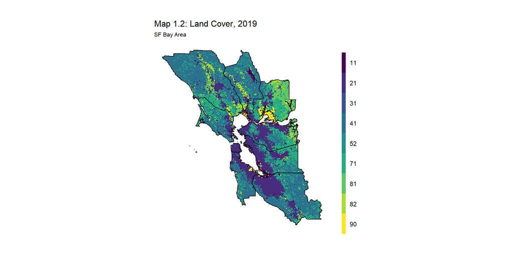

```r
LC_DIR = 'data/sf_land_cover_project'

lc_year_path = function(year, folder = paste(DIR, LC_DIR, sep='/'))
{
  year = year %>% as.character()
  path = paste('sf', year, 'land_cover.tif', sep='_') %>%
    paste(folder, ., sep='/')
  return (path)}

raster_download = function(year){
  lc_year_path(year) %>%
    raster(.) #%>%
    #projectRaster(., crs = CA_proj$proj4string)
}

raster_crop = function(focus_geom, extent_geom=sf.extent, reference_geom=sf.MSA){
  focus_geom %>%
    crop(., extent_geom) %>%
    mask(., reference_geom)
}

sf.lc.2001 =
  raster_download(2001) %>%
  raster_crop(.)

sf.lc.2009 =
  raster_download(2009) %>%
  raster_crop(.)

sf.lc.2019 =
  raster_download(2019) %>%
  raster_crop(.)

ggplot() +
  geom_raster(data=rast(sf.lc.2019) %>% na.omit %>% filter(value > 0),
              aes(x,y,fill=as.factor(value))) +
  scale_fill_viridis(discrete=TRUE, name ="") +
  geom_county() +
  labs(title = "Map 1.2: Land Cover, 2019", subtitle='SF Bay Area') +
  mapTheme #+
```

```r
  #theme(legend.direction="horizontal")
```

Looking at Map 1.2, you can see the 2019 Land Cover for the Bay Area. As you can probably guess, classification 21 is developed areas. It is also interesting how stagnated the developed and undeveloped areas are. Besides the natural geographic borders, the Bay Area has numerous nature conservancies, parks, and land trusts that surround the developed areas – forming an informal urban growth boundary. This lack of room to grow will be an ongoing narrative in this report.

*(Mapper’s Note: I reclassified some Land Covers in ArcGIS [e.g. made classes 21-24 all 21] so it would be easier to filter)*

```r
# fishnet from land change raster
sf.fish =
  # land change raster
  sf.lc.2001 %>%
  raster_to_fishnet() %>%
  rename_first_col(., 'lc.2001') %>%
  #filter(!is.na(lc.2001)) %>%
  # get id for fishnet
  rownames_to_column("id.fishnet") %>%
  mutate(id.fishnet = as.numeric(id.fishnet)) %>%
  # as sf with the main projection
  st_sf(., crs=CA_proj)

sf.fish$id.county =
  st_join_as_col(
    sf.fish %>%
      st_centroid(),
    sf.counties %>%
      dplyr::select(name),
    'name'
    )
## Note: Using an external vector in selections is ambiguous.
## i Use `all_of(cols)` instead of `cols` to silence this message.
## i See <https://tidyselect.r-lib.org/reference/faq-external-vector.html>.
## This message is displayed once per session.

sf.fish =
  sf.fish %>%
  filter(!is.na(id.county))

# add raster to col
add_raster_as_col = function(
  # raster
  focus_raster,
  # focus col to rename in raster
  # & add to focus_fishnet as column
  focus_col,
  focus_fishnet=sf.fish){
  st_join_as_col(
    focus_fishnet,
    focus_raster %>%
      raster_to_centroid() %>%
      rename_first_col(., focus_col),
    focus_col
    )
}

sf.fish$lc.2001 = add_raster_as_col(sf.lc.2001, 'lc.2001')
sf.fish$lc.2009 = add_raster_as_col(sf.lc.2009, 'lc.2009')
sf.fish$lc.2019 = add_raster_as_col(sf.lc.2019, 'lc.2019')
```

Map 1.3 displays those Land Cover Classifications as a binary of *developed* or *non-developed*. The ‘unofficial urban growth boundaries’ are more noticeable. Especially in San Mateo County (SM), where the peninsula appears to be split in half by preserves. Other noticeable counties are Marin (Mar), Sonoma (Son), and Napa (Nap) which have a fairly large share of undeveloped land – especially compared to San Francisco’s (SF) nearly 100% developed land.

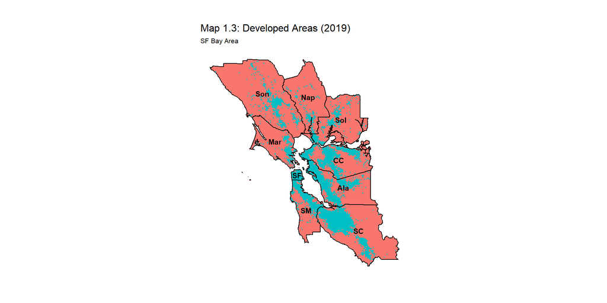

```r
get_dev_col = function(
  focus_col,
  focus_sf = sf.fish,
  dev_lc = c(21,22,23,24),
  dev = 1,
  nondev = 0
    ){
  new_col = focus_sf[[focus_col]]
  new_col[!(new_col %in% dev_lc)] = nondev
  new_col[new_col %in% dev_lc] = dev
  return (new_col)
  }

sf.fish$dev.2001 = get_dev_col('lc.2001')
sf.fish$dev.2009 = get_dev_col('lc.2009')
sf.fish$dev.2019 = get_dev_col('lc.2019')

ggplot() +
  geom_sf(
    data=sf.fish,
    aes(fill=dev.2019 %>% as.factor()),
    color=NA
    ) +
  geom_county(alpha=.5, fill=NA) +
  geom_county_text() +
  labs(title = 'Map 1.3: Developed Areas (2019)', subtitle='SF Bay Area') +
  mapTheme +
  theme()  +
  theme(legend.position = "none")
```

### Land Cover Change, 2009 to 2019

With the 2019 Land Cover in mind, let’s look at how it changed in 10 years. Map 1.4 highlights the new developments . . . the very few of them. It is difficult to full find spatial patterns but they are there. Most of the developments are happing on the urban fringes and along federal highways. With the little amount of developments, it will pose an issue gathering accurate predictors.

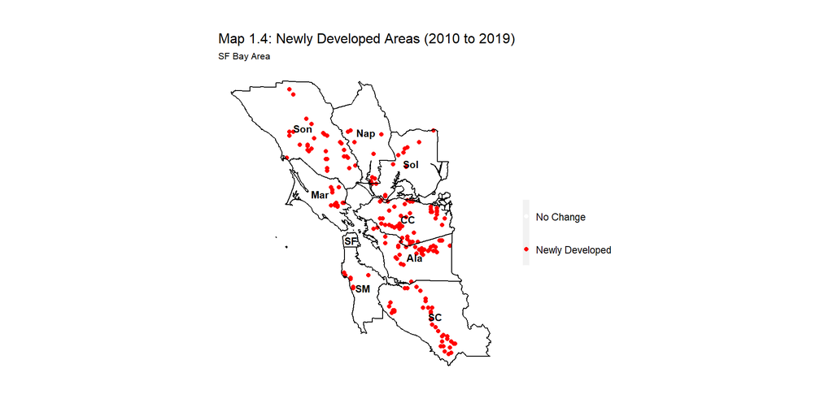

```r
if_lc_same = function(firstcol,secondcol){
  ifelse(
    firstcol == secondcol,
    0,1) %>%
    unname()}

sf.fish$dev_ch.01_09 = if_lc_same(sf.fish$dev.2001, sf.fish$dev.2009)
#sf.fish$dev_ch.01_19 = if_lc_same(sf.fish$dev.2001, sf.fish$dev.2019)
sf.fish$dev_ch.09_19 = if_lc_same(sf.fish$dev.2009, sf.fish$dev.2019)

ggplot() +
  geom_sf(data=sf.fish %>% st_centroid(),
             aes(#x=xyC(sf.lc.00_19)$x, y=xyC(sf.lc.00_19)$y,
                 colour=dev_ch.09_19 %>% as.factor())) +
  scale_color_manual(
    values = c('#FFFFFF', '#FF0000'),
    labels=c("No Change","Newly Developed"),
                       name="") +
  geom_county(alpha=.5, fill=NA) +
  geom_county_text() +
  labs(title = 'Map 1.4: Newly Developed Areas (2010 to 2019)', subtitle='SF Bay Area') +
  mapTheme  #+
```

```r
  #theme(legend.position = "none")
```

Map 1.5 breaks down how this land cover is broken up.

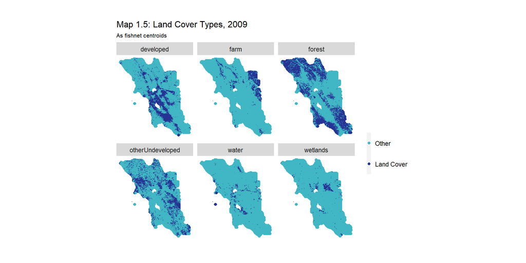

```r
aggregateRaster <- function(inputRasterList, theFishnet) {
  #create an empty fishnet with the same dimensions as the input fishnet
  theseFishnets <- theFishnet %>% dplyr::select()
  #for each raster in the raster list
  for (i in inputRasterList) {
  #create a variable name corresponding to the ith raster
  varName <- names(i)
  #convert raster to points as an sf
    thesePoints <-
      rasterToPoints(i) %>%
      as.data.frame() %>%
      st_as_sf(coords = c("x", "y"), crs = st_crs(theFishnet)) %>%
      filter(.[[1]] == 1)
  #aggregate to the fishnet
    thisFishnet <-
      aggregate(thesePoints, theFishnet, length) %>%
      mutate(!!varName := ifelse(is.na(.[[1]]),0,1))
  #add to the larger fishnet
    theseFishnets <- cbind(theseFishnets,thisFishnet)
  }
  #output all aggregates as one large fishnet
   return(theseFishnets)
}

agg_raster = function(lc_raster, focus_fishnet=sf.fish){
  developed = lc_raster == 21 | lc_raster == 22 | lc_raster == 23 | lc_raster == 24
  forest = lc_raster == 41 | lc_raster == 42 | lc_raster == 43
  farm = lc_raster == 81 | lc_raster == 82
  wetlands = lc_raster == 90 | lc_raster == 95
  otherUndeveloped = lc_raster == 52 | lc_raster == 71 | lc_raster == 31
  water = lc_raster == 11

  names(developed) = "developed"
  names(forest) = "forest"
  names(farm) = "farm"
  names(wetlands) = "wetlands"
  names(otherUndeveloped) = "otherUndeveloped"
  names(water) = "water"

  lc.agg = c(developed,forest,farm,wetlands,otherUndeveloped,water)

  agg_raster =
    aggregateRaster(lc.agg, focus_fishnet) %>%
    mutate_if(is.numeric,as.factor)
  return(agg_raster)
}

sf.agg.2001 = agg_raster(sf.lc.2001)
sf.agg.2009 = agg_raster(sf.lc.2009)
sf.agg.2019 = agg_raster(sf.lc.2019)

sf.agg.2009 %>%
  gather(var,value,developed:water) %>%
  st_cast("POLYGON") %>%    #just to make sure no weird geometries slipped in
  mutate(X = xyC(.)$x,
         Y = xyC(.)$y) %>%
  ggplot(.) +
    geom_sf(data=sf.MSA) +
    geom_point(aes(X,Y, colour=as.factor(value))) +
    #geom_sf(data=sf.lc.00_19 %>% na.omit %>% filter(sf.lc.00_19==1),
    #        color='red', fill=NA) +
    facet_wrap(~var) +
    scale_colour_manual(values = palette2,
                        labels=c("Other","Land Cover"),
                        name = "") +
    labs(title = "Map 1.5: Land Cover Types, 2009",
         subtitle = "As fishnet centroids") +
   mapTheme
```

## 1.3. Population Data (2000, 2010, & 2019)

The next step is understanding how those areas have been populated. So we will bring in Decennial & ACS Census Tracts of population.

Map 1.6 highlights both a visualization of the 2019 population and how the census tract data (1.6A) is attached to our raster/fishnets (1.6B)S. The tracts highlight the changes in population in short distances – as a result of inconsistent densities *and* census boundaries. By ‘interpolating’ the census tract data to a ‘heat map’, we can better capture a smoothed out population estimation in our fishnets. The fishnets, based on the 1000 meter raster, provide even boundaries to compare data over time and geographies.

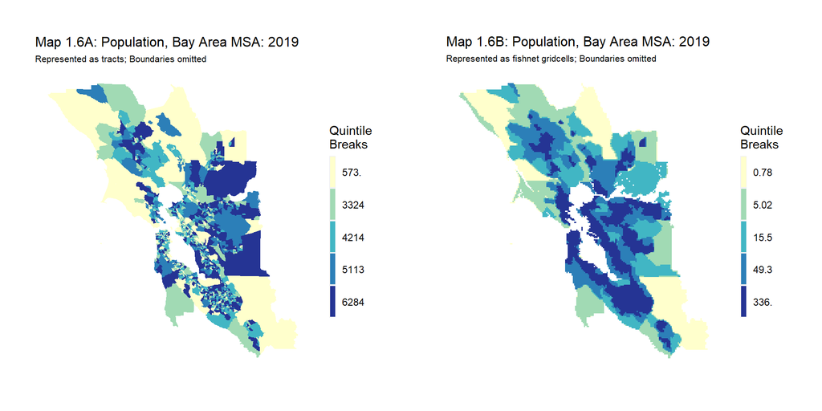

```r
sf_bay.counties =
  c(
    "Alameda", "Contra Costa", "Marin",
    "Napa", "San Francisco", "San Mateo",
    "Santa Clara", "Solano", "Sonoma"
                  )

path_pop_00 = 'data/census/sf_pop_blockgroup_2000.geojson'
sf.pop.00 =
  st_read(path_pop_00)
  # get_decennial(geography = "block group", variables = "P001001", year = 2000,
  #               state = 06, geometry = TRUE,
  #               county=sf_bay.counties
  #               ) %>%
  # rename(pop.2000 = value) %>%
  # st_transform(CA_proj)
#sf.pop.00 %>% st_write(path_pop_00)

path_pop_10 = 'data/census/sf_pop_blockgroup_2010.geojson'
sf.pop.10 =
  st_read(path_pop_10)
  # get_decennial(geography = "block group", variables = "P001001", year = 2010,
  #               state = 06, geometry = TRUE,
  #               county=sf_bay.counties) %>%
  # rename(pop.2010 = value) %>%
  # st_transform(CA_proj) %>%
  # st_buffer(-1)
#sf.pop.10 %>% st_write(path_pop_10)

# Specify which variable(s) you would like to grab. Here, only one (Total Population) is listed, but you could add more to the call.
acs_vars = c("B02001_001E")

# Using "tract" as the geography and 2019 as the year, download data data for the Bay Area MSA counties listed.
sf.pop.19 = get_acs(geography = "tract",
                        variables = acs_vars,
                        year = 2019,
                        state = 06,
                        geometry = TRUE,
                        #output = "wide",
                        county=sf_bay.counties) %>%
                transmute(pop.2019 = estimate) %>%
  st_transform(CA_proj) %>%
  st_buffer(-1)

get_demo_col = function(focus_demo, focus_sf=sf.fish){
  focus_demo_col =
    st_interpolate_aw(
      focus_demo,
      focus_sf,
      extensive=TRUE,keep_NA=TRUE
      ) %>%
    st_drop_geometry()
  focus_demo_col[is.na(focus_demo_col)] = 0
  return(focus_demo_col %>% pull(1))
  }

sf.fish$pop.00 = get_demo_col(sf.pop.00["pop.2000"])
sf.fish$pop.10 = get_demo_col(sf.pop.10["pop.2010"])
sf.fish$pop.19 = get_demo_col(sf.pop.19["pop.2019"])

sf.fish$pop_pct_ch.00_10 = (sf.fish$pop.10-sf.fish$pop.00)/sf.fish$pop.10
sf.fish$pop_pct_ch.10_19 = (sf.fish$pop.19-sf.fish$pop.10)/sf.fish$pop.19

sf.fish[is.na(sf.fish$pop_pct_ch.00_10)|mapply(is.infinite,sf.fish$pop_pct_ch.00_10), 'pop_pct_ch.00_10'] = 0
sf.fish[is.na(sf.fish$pop_pct_ch.10_19)|mapply(is.infinite,sf.fish$pop_pct_ch.10_19), 'pop_pct_ch.10_19'] = 0

rm(sf.pop_fish.00)
rm(sf.pop_fish.10)

grid.arrange(
  ggplot() +
    geom_sf(data=sf.pop.19, aes(fill=factor(ntile(pop.2019,5))),colour=NA) +
    scale_fill_manual(values = palette5,
                      labels=substr(quintileBreaks(sf.pop.19,"pop.2019"),1,4),
                     name="Quintile\nBreaks") +
    labs(title="Map 1.6A: Population, Bay Area MSA: 2019",
         subtitle="Represented as tracts; Boundaries omitted") +
    mapTheme,

  ggplot() +
    geom_sf(data=sf.fish, aes(fill=factor(ntile(pop.19,5))),colour=NA) +
    scale_fill_manual(values = palette5,
                     labels=substr(quintileBreaks(sf.fish,"pop.19"),1,4),
                     name="Quintile\nBreaks") +
    labs(title="Map 1.6B: Population, Bay Area MSA: 2019",
         subtitle="Represented as fishnet gridcells; Boundaries omitted") +
    mapTheme,
  ncol=2)
```

```r
# rm(sf.pop.00)
# rm(sf.pop.10)
```

Maps 1.7 show how the population was distributed in 2000 & 2010.

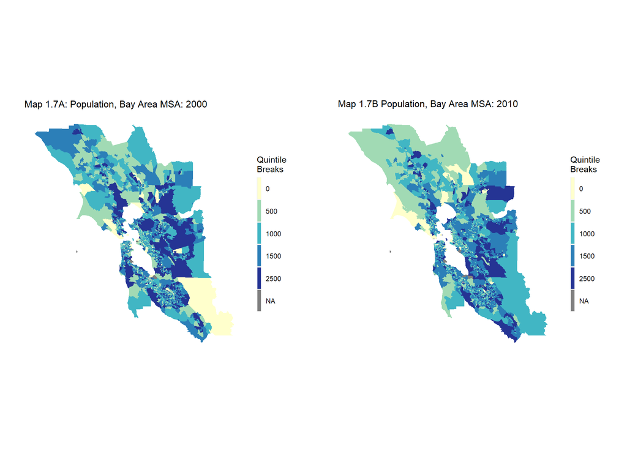

```r
pbreaks = c(0,500, 1000, 1500, 2500, 30000)
plabs = c('0','500','1000', '1500', '2500')
grid.arrange(
  ggplot() +
    geom_sf(data = sf.pop.00, aes(fill=factor(cut(pop.2000, breaks=pbreaks))), colour=NA) +
    scale_fill_manual(values = palette5,
                      labels=plabs,
                     name="Quintile\nBreaks") +
    labs(title="Map 1.7A: Population, Bay Area MSA: 2000") +
    mapTheme,
  #factor(ntile(pop.2010,5)))
  ggplot() +
    geom_sf(
      data = sf.pop.10,
      aes(fill=factor(cut(pop.2010, breaks=pbreaks))), colour=NA) +
    scale_fill_manual(values = palette5,
                      labels=plabs,
                     name="Quintile\nBreaks") +
    labs(title="Map 1.7B Population, Bay Area MSA: 2010") +
  mapTheme, ncol=2)
```

## 1.4 Transit Stops & Routes (2008 & 2021)

Inconsistent boundaries and values are a common theme with Bay Area governance – especially with the 27 transit agencies operating across 9 counties [[source](https://www.mercurynews.com/2021/04/17/borenstein-27-bay-area-transit-agencies-no-wonder-travel-is-so-hard/)].

Map 1.8 highlights the inconsistency of the transit agencies with every color representing a different transit operator. This balkanization has made it difficult to coordinate the addition of Transit Oriented Developments and *density in general*. Outside of the Bay Area Rapid Transit’s (BART) immediate reach of San Francisco & Oakland, it is very difficult to navigate the city without cars. Even though other counties have some form of light rail and commuter rail, the lack of connectivity makes a transit line near impotent. So even SF & East Bay areas with a BART station still have to drive to South & North Bay.

```r
TRANS_DIR = paste(DIR, 'data/trans', sep='/')

bad.transit = c('Ferry', 'Cable car')

path = "transit_routes_2008/sf_routes_2008.shp" %>%
    paste(TRANS_DIR, ., sep='/')
sf.troutes.2008 =
  st_read(path) %>%
  transmute(
    route.type = ifelse(CLASS%in%c("Rapid Rail", "Commuter Rail"), 'Rail', CLASS),
    route.agency = AGENCYNAME) %>%
  filter(!(route.type %in% bad.transit)) %>%
  st_transform(proj_crs) %>%
  mutate(year = 2008)
```

Reading layer `sf_routes_2008' from data source`C:_routes_2008_routes_2008.shp’ using driver `ESRI Shapefile’ Simple feature collection with 1266 features and 6 fields Geometry type: LINESTRING Dimension: XY Bounding box: xmin: -123.0544 ymin: 36.97512 xmax: -121.2598 ymax: 38.80635 Geodetic CRS: WGS 84

```r
path = "transit_routes_2021/sf_routes_2021.shp" %>%
    paste(TRANS_DIR, ., sep='/')
sf.troutes.2021 =
  st_read(path) %>%
  transmute(route.type = ifelse(
    route_type=="Tram, Streetcar, Light rail", 'Light Rail',
      route_type),
    route.agency = agency_nm) %>%
  filter(!(route.type %in% bad.transit)) %>%
  st_transform(proj_crs) %>%
  mutate(year = 2021)
```

Reading layer `sf_routes_2021' from data source`C:_routes_2021_routes_2021.shp’ using driver `ESRI Shapefile’ Simple feature collection with 5931 features and 8 fields Geometry type: MULTILINESTRING Dimension: XY Bounding box: xmin: -123.0544 ymin: 36.97474 xmax: -121.0805 ymax: 38.90383 Geodetic CRS: WGS 84

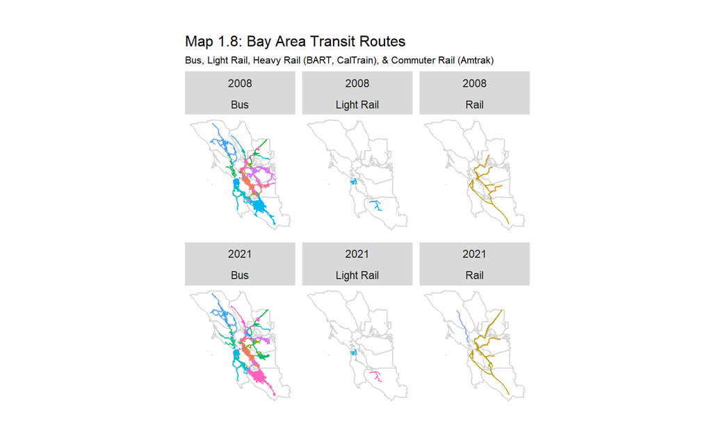

```r
sf.troutes =
  rbind(
    sf.troutes.2008,
    sf.troutes.2021
  )  %>%
  st_intersection(sf.counties)


ggplot() +
  geom_county(color='lightgrey') +
  geom_sf(data=sf.troutes, aes(color=route.agency), show.legend = FALSE) +
  facet_wrap(year~route.type, ncol=3) +
  labs(title = "Map 1.8: Bay Area Transit Routes", subtitle = 'Bus, Light Rail, Heavy Rail (BART, CalTrain), & Commuter Rail (Amtrak)') +
  mapTheme
```

```r
# sf.troutes.2008 = sf.troutes %>%
#   filter(year==2008) %>%
#   as_Spatial(.) %>%
#   gBuffer(., byid=F, width=20) %>%
#   st_as_sf(.)
# sf.troutes.2021 = sf.troutes %>%
#   filter(year==2021) %>%
#   as_Spatial(.) %>%
#   gBuffer(., byid=F, width=20) %>%
#   st_as_sf(.)
```

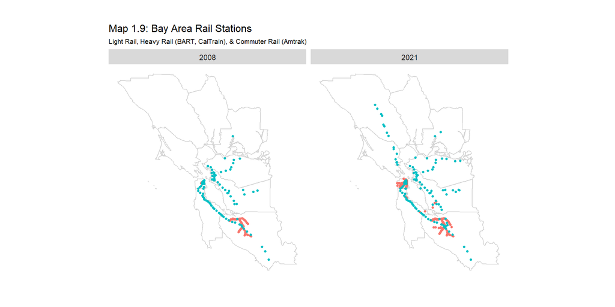

```r
bad.stations = c(NA, "Cable Tram", "Bus", "BRT", "Ferry", "Municipal Airport", "International Airport", "Ferry Terminal", "Military Airport")


TRANS_DIR = paste(DIR, 'data/trans', sep='/')

path = "transit_stations_2008/sf_stations_2008.shp" %>%
    paste(TRANS_DIR, ., sep='/')
sf.stations.2008 =
  st_read(path) %>%
  filter(!(CLASS %in% bad.stations)) %>%
  transmute(
    route.type = ifelse(
      CLASS %in% c("Light Rail Station"), 'Light Rail',
      ifelse(
        CLASS %in% c("Rapid Rail Station", "Commuter Rail Station"), "Rail",
        CLASS
      )),
  ) %>%
  mutate(year = 2008)

path = "transit_stations_2021/sf_stations_2021.shp" %>%
    paste(TRANS_DIR, ., sep='/')
sf.stations.2021 =
  st_read(path) %>%
  filter(!(route_type %in% bad.stations)) %>%
  transmute(
    route.type = ifelse(
      route_type%in%c("Tram, Streetcar, Light Rail"), 'Light Rail',
      route_type),
  ) %>%
  mutate(year = 2021)

sf.stations =
  rbind(
    sf.stations.2008,
    sf.stations.2021
  ) %>%
  st_transform(proj_crs) %>%
  st_intersection(sf.counties)

sf.stations.2008 = sf.stations %>%
  filter(year==2008)%>%
  filter(route.type!='Bus') %>%
  #as_Spatial(.) %>%
  #gBuffer(., byid=F, width=20) %>%
  st_buffer(100) %>%
  st_union(.) %>%
  st_as_sf(.)
sf.stations.2021 = sf.stations %>%
  filter(year==2021) %>%
  filter(route.type!='Bus') %>%
  #as_Spatial(.) %>%
  #gBuffer(., byid=F, width=20) %>%
  st_buffer(100) %>%
  st_union(.) %>%
  st_as_sf(.)

ggplot() +
  geom_county(color='lightgrey') +
  #geom_sf(data=sf.troutes %>% filter(route.type!='Bus'), aes(color=route.type), show.legend = FALSE) +
  geom_sf(data=sf.stations, aes(color=route.type), show.legend = FALSE, size=1) +
  facet_wrap(~year) +
  labs(title = "Map 1.9: Bay Area Rail Stations", subtitle = 'Light Rail, Heavy Rail (BART, CalTrain), & Commuter Rail (Amtrak)') +
  mapTheme
```

## 1.5. Highways (2020)

Map 1.10 highlights the federal and state highways that connect the bay area. For many commuters, this is their main option. This reliance on highways and the housing shortage has promoted bedroom communities leapfrog developments *(over the natural preserves)*. This could explain the few developments we observed from 2009 to 2019.

Like many of the datasets, these highways came from the Metropolitan Transportation Commission’s Open Data [[source](https://opendata.mtc.ca.gov/datasets/MTC::san-francisco-bay-region-roadways/explore?location=37.871686%2C-122.367566%2C8.69)]

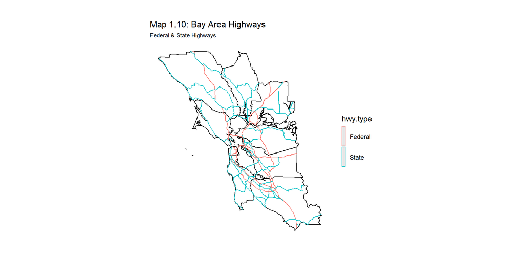

```r
TRANS_DIR = paste(DIR, 'data/trans', sep='/')

path =
  "roadways_2021/sf_roadways.shp" %>%
  paste(TRANS_DIR, ., sep='/')

hwy.fed = c('I', 'U')
hwy.state = c('S')
hwy.types = c(hwy.fed, hwy.state)

#Route Type Code
#C  County
#I  Interstate
#M  Common Name
#O  Other
#S  State recognized
#U  U.S.
## https://www.census.gov/library/reference/code-lists/route-type-codes.html

hwy.avg_lane_width = 13 #feet
hwy.fed_lanes = 6
hwy.state_lanes = 3

sf.hwy =
  st_read(path) %>%
  st_transform(proj_crs)%>%
  filter(!is.na(rttyp), rttyp %in% hwy.types) %>%
  mutate(
    hwy.type = ifelse(
      rttyp %in% hwy.fed, 'Federal',
      'State'
    )
  ) %>%
  group_by(hwy.type) %>%
  summarize(geometry = st_union(geometry)) %>%
  mutate(
    geometry = geometry %>%
      st_buffer(ifelse(
        hwy.type == 'Federal', hwy.avg_lane_width * hwy.fed_lanes,
        hwy.avg_lane_width * hwy.state_lanes
      ))
  )

ggplot() +
  geom_county() +
  geom_sf(data=sf.hwy, aes(color=hwy.type)) +
  labs(title = "Map 1.10: Bay Area Highways", subtitle = 'Federal & State Highways') +
  mapTheme
```

After importing in those three transporation datasets, we will then determine the distance between them and the fishnets. Map 1.11 highlights how the distance was found between the federal highways and the main fishnet dataset.

[figure not shown]

```r
emptyRaster = sf.lc.2001
emptyRaster[] = NA

get_dist_raster = function(focus_df, focus_fishnet=sf.fish){
  highway_raster <-
    focus_df %>%
    as(.,'Spatial') %>%
    rasterize(., emptyRaster)

  highway_raster_distance <- distance(highway_raster)
  names(highway_raster_distance) <- "distance_highways"

  highwayPoints <-
    rasterToPoints(highway_raster_distance) %>%
     as_tibble(.) %>%
     st_as_sf(coords = c("x", "y"), crs = proj_crs)

  highwayPoints_fishnet <-
    aggregate(highwayPoints, focus_fishnet, mean) %>%
    mutate(distance_highways = ifelse(is.na(distance_highways),0,distance_highways))
  return(
    highwayPoints_fishnet %>%
      st_drop_geometry() %>%
      pull(distance_highways)
           )
  }

path = paste(DIR, 'data/sf_transpo_fishnets/sf_transpo_fishnets.geojson', sep='/')
# sf.fish %>%
#   dplyr::select(c(
#     id.fishnet, hwy.fed, rail.2008, rail.2021
#   )) %>%
#   st_write(path)
sf.transpo = st_read(path)

# sf.fish$hwy.state =
#   add_raster_as_col(get_dist_raster(sf.hwy), 'hwy.state')
sf.fish$hwy.fed = sf.transpo$hwy.fed
  # sf.hwy %>%
  # st_sf(.) %>%
  # filter(hwy.type=='Federal') %>%
  # dplyr::select(-hwy.type, geometry) %>%
  # get_dist_raster(.)

# sf.fish$bus.2008 =
#   sf.troutes.2008 %>%
#   #filter(year==2008, route.type== 'Bus') %>%
#   add_raster_as_col(get_dist_raster(.), 'bus.2008')
# sf.fish$bus.2021 =
#   sf.troutes %>%
#   #filter(year==2021, route.type== 'Bus') %>%
#   add_raster_as_col(get_dist_raster(.), 'bus.2021')

sf.fish$rail.2008 = sf.transpo$rail.2008
  # sf.stations.2008 %>%
  # transmute(geometry=x) %>%
  # st_sf(.,sf_column_name='geometry') %>%
  # dplyr::select(geometry) %>%
  # #filter(year==2008) %>%
  # get_dist_raster(.)
sf.fish$rail.2021 = sf.transpo$rail.2021
  # sf.stations.2021 %>%
  # transmute(geometry=x) %>%
  # st_sf(.,sf_column_name='geometry') %>%
  # dplyr::select(geometry) %>%
  # #filter(year==2021) %>%
  # get_dist_raster(.)

rm(sf.transpo)

ggplot() +
  geom_point(
    data=sf.fish,
    aes(x=xyC(sf.fish)[,1], y=xyC(sf.fish)[,2],
                 colour=factor(ntile(hwy.fed,5))),size=1.5) +
  scale_colour_manual(values = palette5,
                      labels=substr(quintileBreaks(sf.fish,"hwy.fed"),1,8),
                      name="Quintile\nBreaks") +
  geom_sf(data=sf.troutes %>% filter(route.type!='Bus'), colour = "red") +
  geom_county() +
  labs(title = "Map 1.11: Distance to Highways",
       subtitle = "As fishnet centroids; Highways visualized in red") +
  mapTheme
```

## 1.6. The Spatial Lag of Development

As we get closer to predicting where the developments happened, an important dataset is getting the ‘spatial lag’ of where those developments took place. Spatial lag can come in a few forms; but for our analysis, we will be looking at the two *nearest neighbor’s* values of each fishnet cell. As depicted in Map 1.12, spatial lag allows our model to consider the neighboring cell’s values when trying to form a prediction.

[figure not shown]

```r
nn_function = function(measureFrom,measureTo,k) {
  #convert the sf layers to matrices
  measureFrom_Matrix =
    as.matrix(measureFrom)
  measureTo_Matrix =
    as.matrix(measureTo)
  nn =
    get.knnx(measureTo, measureFrom, k)$nn.dist
    output =
    as.data.frame(nn) %>%
    rownames_to_column(var = "thisPoint") %>%
    gather(points, point_distance, V1:ncol(.)) %>%
    arrange(as.numeric(thisPoint)) %>%
    group_by(thisPoint) %>%
    summarize(pointDistance = mean(point_distance)) %>%
    arrange(as.numeric(thisPoint)) %>%
    dplyr::select(-thisPoint) %>%
    pull()

  return(output)
}

nn_dev_year = function(focus_agg_raster, focus_fishnet=sf.fish, k=2){
  nn_function(
    xyC(focus_fishnet),
    xyC(focus_agg_raster %>% filter(developed==1)),
    k)
}

sf.fish$dev.lag.2001 = nn_dev_year(sf.agg.2001)
sf.fish$dev.lag.2009 = nn_dev_year(sf.agg.2009)
sf.fish$dev.lag.2019 = nn_dev_year(sf.agg.2019)


ggplot() +
  geom_sf(data=sf.MSA) +
  geom_point(data=sf.fish,
             aes(x=xyC(sf.fish)[,1], y=xyC(sf.fish)[,2],
                 colour=factor(ntile(dev.lag.2019,5))), size=1.5) +
  scale_colour_manual(
    values = palette5,
    labels=substr(quintileBreaks(sf.fish,"lag.dev.2009"),1,7),
                     name="Quintile\nBreaks") +
  geom_county_text() +
  labs(title = "Map 1.12: Spatial Lag to 2009 Development",
       subtitle = "As fishnet centroids") +
  mapTheme
```

## 1.7. Incoporated Cities

In a similar vein to referencing counties, I am highlighting if a cell is in an incorporated city or not. With an acknowledgement of the cell being incorporated, it might be less likely to have availble land. On the other hand, unincorporated areas are also land preserves without development.

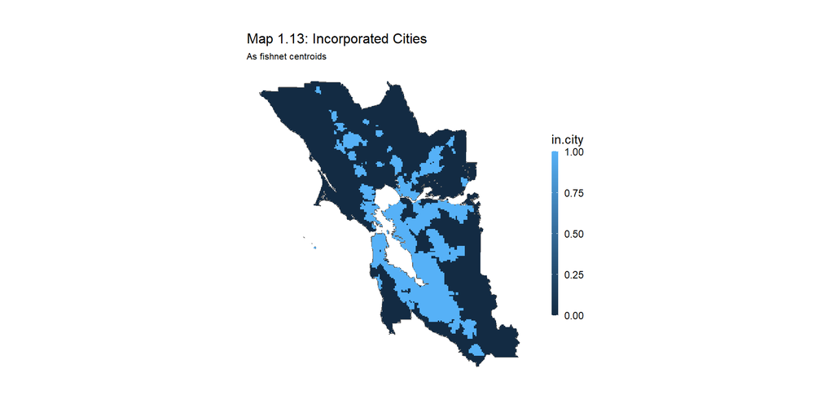

```r
path = paste(DIR, "data/sf_cities/sf_cities.shp", sep='/')
sf.cities =
  st_read(path) %>%
  st_transform(proj_crs)

sf.fish$in.city =
  st_join(
    sf.fish,
    sf.cities %>%
      st_union() %>%
      st_sf() %>%
      mutate(in.city = 1),
    left = TRUE
  ) %>%
  st_drop_geometry() %>%
  pull(in.city)

sf.fish[is.na(sf.fish$in.city),'in.city'] = 0

ggplot() +
  geom_sf(data=sf.MSA) +
  geom_sf(data=sf.fish,
          aes(fill=in.city), color=NA) +
  labs(title = "Map 1.13: Incorporated Cities",
       subtitle = "As fishnet centroids") +
  mapTheme
```

## 1.8. Correlations

The final step before fitting a model to predict for New Developments between 2010 to 2019, is to understand how the variables related to the dependent variable and each other. We want predictor variables that have a relationship to New Developments but not too much relationship with each other. If a model has too much multicollinearity (similarity between variables), the model’s overall effects could be diluted with multiple variables predicting the same thing.

### Pearson Correlation

A Pearson Correlation helps measure the linear relationship between continuous variables – on a scale of -1 (negative correlation), 0 (no correlation), or 1 (postive correlation). A rule of thumb is that a correlation above .8 or below -.8 means they are highly related.

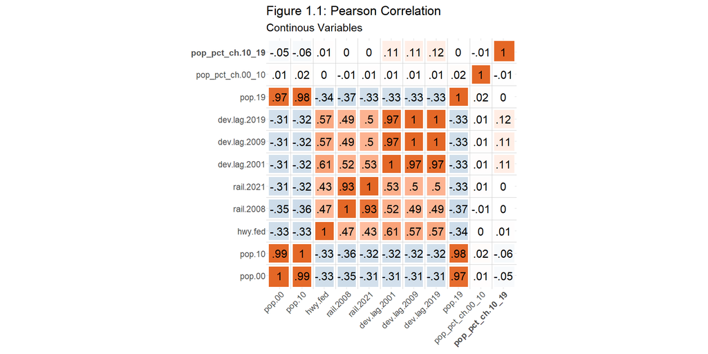

```r
vars.ivs.cont =
  c(
    #"id.fishnet", "lc.2001","geometry","id.county",
    #"lc.2009", "lc.2019", "dev.2001", "dev.2009",
    #"dev.2019", "dev_ch.01_09", "dev_ch.09_19",
    "pop.00", "pop.10", "hwy.fed", "rail.2008", "rail.2021",
    "dev.lag.2001", "dev.lag.2009", "dev.lag.2019", #"in.city",
    "pop.19", "pop_pct_ch.00_10","pop_pct_ch.10_19"
  )

sf.cont =
  sf.fish %>%
  dplyr::select(c(vars.ivs.cont)) %>%
  st_drop_geometry(.)
## Note: Using an external vector in selections is ambiguous.
## i Use `all_of(vars.ivs.cont)` instead of `vars.ivs.cont` to silence this message.
## i See <https://tidyselect.r-lib.org/reference/faq-external-vector.html>.
## This message is displayed once per session.

plot = ggcorr_full(sf.cont, "pop_pct_ch.10_19",
            title = "Figure 1.1: Pearson Correlation",
            subtitle = "Continous Variables"
)
print(plot)
```

Figure 1.1 shows a pearson correlation among the potential continuous variables. Some of the positive relationships between variables are concerning. Especially total population counts (pop.XX), distances to rail stations (rail.20XX), and development spatial lags (dev.lag.20XX). We will likely have to choose between them in the next correlation test.

### T-Test & Mann–Whitney–Wilcoxon (MWW) Test

The first test is the Two Independent Samples **T-Test** which measures the means, standard deviation, & number of observations of the two binaries. The T-Statistic is the ratio of difference in the means – higher suggests the means are separate, lower suggests they are similar. A small p-value (<.001) suggests that the statistic is valuable.

The second test is the **Wilcoxon rank-sum / Mann-Whitney-Wilcoxon** (MWW) test which measures if the two binary populations of the binary come from distinct populations. It is important to use the MWW test as it doesn’t assume the variables are normally distributed. This is helpful as the probability distribution suggests many of the variables have skewed distributions. For the MWW Statistic, significantly separate values have low P-values (<0.05).

```r
var.dv = 'dev_ch.09_19'

var.ivs = c(vars.ivs.cont)
cont_vars = var.ivs
focus_df = sf.fish %>%
    dplyr::select(c(
      var.dv,
      cont_vars
      ))
## Note: Using an external vector in selections is ambiguous.
## i Use `all_of(var.dv)` instead of `var.dv` to silence this message.
## i See <https://tidyselect.r-lib.org/reference/faq-external-vector.html>.
## This message is displayed once per session.
## Note: Using an external vector in selections is ambiguous.
## i Use `all_of(cont_vars)` instead of `cont_vars` to silence this message.
## i See <https://tidyselect.r-lib.org/reference/faq-external-vector.html>.
## This message is displayed once per session.

ttest_df = data.frame()

for (cont_var in cont_vars){

  bin_df = focus_df %>%
    dplyr::select(cont_var, var.dv) %>%
    filter(!is.na(cont_var))

  bin_FALSE = bin_df %>%
    filter(.data[[var.dv]]==0) %>%
    pull(cont_var)
  bin_TRUE = bin_df %>%
    filter(.data[[var.dv]]==1) %>%
    pull(cont_var)

  bin_test =
    t.test(bin_FALSE, bin_TRUE, alternative = "two.sided")

  tstat = bin_test$statistic %>% as.numeric() %>% round(2)
  doff = bin_test$parameter %>% as.numeric() %>% round()
  pval = bin_test$p.value %>%
    round_thresh(., thresh = .001,  digits = 3)
  mean_FALSE =
    mean(bin_FALSE, na.rm=TRUE) %>% round(1)
  mean_TRUE =
    mean(bin_TRUE, na.rm=TRUE) %>% round(1)

  ttest_df = rbind(
    ttest_df,
    c(cont_var, mean_FALSE,mean_TRUE,tstat,doff,pval)
  )}
## Note: Using an external vector in selections is ambiguous.
## i Use `all_of(cont_var)` instead of `cont_var` to silence this message.
## i See <https://tidyselect.r-lib.org/reference/faq-external-vector.html>.
## This message is displayed once per session.

colnames(ttest_df) =
  c('iv', "FALSE", "TRUE",
    "Statistic", "DF", 'P-Value')

tab_num = 2
title = "Table 1.1: T-Test & MWW of Binary Variables"

sf.cont.MWW =
  df_corr_data(
    dv = var.dv,
    ivs = cont_vars,
    test = 'MWW'
  )

new_cols = c('iv', "No New Land Use Change", "New Development Change",
    "Statistic", 'DF', 'P-Value', 'Statistic', 'P-Value')

sf.cont.ttest =
  ttest_df

 merge(
    sf.cont.ttest,
    sf.cont.MWW,
    on='iv',
    sort=FALSE
    ) %>%
  mutate(
    MWW = MWW %>% as.numeric() %>% count_format()
  ) %>%
  kable(., caption = title, label = NA,
        col.names = new_cols) %>%
  kable_styling() %>%
  add_header_above(
    header=
      c(' '=1,'Mean'=2,'T-Test'=3, 'MWW'=2)
  ) %>%
  kableExtra::footnote(
    alphabet =
      c(
        "Two independent samples t-test",
        "Wilcoxon rank sum test",
        "significance level: 0.05"
               ))
```

Table 1.1: T-Test & MWW of Binary Variables

| iv | Mean No New Land Use Change | Mean New Development Change | T-Test Statistic | T-Test DF | T-Test P-Value | MWW Statistic | MWW P-Value |
| --- | --- | --- | --- | --- | --- | --- | --- |
| pop.00 | 369.3 | 431.5 | -1.59 | 198 | .115 | 798,692 | < .001 |
| pop.10 | 389 | 485.9 | -2.26 | 195 | .025 | 773,974 | < .001 |
| hwy.fed | 47460.9 | 29051.5 | 10.84 | 189 | < .001 | 218,835 | < .001 |
| rail.2008 | 252200.7 | 213993.5 | 6.42 | 187 | < .001 | 2,010,564 | < .001 |
| rail.2021 | 222767.5 | 179304.8 | 6.58 | 186 | < .001 | 2,057,138 | < .001 |
| dev.lag.2001 | 12112.7 | 3992.7 | 63.21 | 488 | < .001 | 242,445 | < .001 |
| dev.lag.2009 | 11741.5 | 3757.5 | 80.44 | 1156 | < .001 | 2,427,794 | < .001 |
| dev.lag.2019 | 11628.9 | 1697.5 | 124.8 | 15408 | < .001 | 291,924 | < .001 |
| pop.19 | 417.6 | 520.9 | -2.59 | 199 | .01 | 810,919 | < .001 |
| pop_pct_ch.00_10 | -0.4 | 0 | -4.66 | 967 | < .001 | 1,389,082 | < .001 |
| pop_pct_ch.10_19 | 0.1 | -0.1 | 2.52 | 186 | .012 | 1,886,752 | < .001 |

<sup>a</sup> Two independent samples t-test  
<sup>b</sup> Wilcoxon rank sum test  
<sup>c</sup> significance level: 0.05

Let’s take in Table 1.1. The first two columns highlight the differences in means between cells of *No New Land Use Change* and *New Developments*. Even though some of the two means seem completely different *(e.g. distance to federal highways [hwy.fed])*, the means could be skewed by an irregular distribution. The T-Test statistics & p-values tell us that many variables *are* significant – with the 2000 & 2010 populations being the least distinct. Because of their similarity to the 2019 population, we will remove them.

For the MWW statistic & p-value, it suggests that almost all of the variables are significant. If I had to remove some variables because of multicollinearity concerns, I would take out some of the develpment lags and one of the highways.

The large amount of significant variables could be great sign. But at the same time, the little amount of development could be too small of a sample size. Also, many cells could share the same metrics as the 2010-19 new developments, but just simply not be developed for a more niche reason.